# Aoyama OE2 - Spring Semester 2026

Chris Elvin

2026-07-10

### Today

#### Warmup question

```
[1] "What do you like to eat?"
```

| name | answer |
| --- | --- |
| TAKEMOTO MEIBI | My favorite food is Ramen. |
| INO YUYA | pizza. |
| SAKANASHI KANO | I like Udon. |
| YAMAGUCHI KAHO | I like hamburger. |
| TEZUKA ASUMI | My favorite food is sushi. |
| YAJIMA KOUDAI | I like to eat meat |
| AKIYAMA RURUKO | I like grapes. |
| YUZAWA SANA | I like Curry and rice. |
| SAKAE AKARI | I like tomato. |
| OTANI WASEI | I like sushi |
| KUJIRAOKA SERA | I like cold noodles. |
| MATSUHISA HONOKA | I like udon. |
| SAITOU MIREI | I like pudding. |
| FUKAYA MINA | I like Gyoza the best. |
| TEJIMA SEIYA | Sushi |
| KIMURA HARUA | I like Chinese food. |
| CHIKUMA KAHO | I like melon. |
| SAWADA MANATO | I like ramen. |
| TAKAHASHI SAKI | I like matcha ice cream so much. |
| KIHARA MOE | I love corn. |
| KONDO AN | I like gyoza. |
| ONISHI NANAKA | Cakes |
| KUBOTA ANNA | I like pudding. |
| YAHAGI AYA | American dog |
| YOSHIZAWA NONOKA | I like summer fruits and vegetables. |
| AKIYAMA RURUKO | I lile grapes. |
| ABE HIKARI | Sweet potet |

#### Discussion Leader Feedback

| leader | preparation | content | fluency | communication | pronunciation | TOTAL |
| --- | --- | --- | --- | --- | --- | --- |

#### Preparation

#### Content

#### Fluency

#### Communication

#### Pronunciation

#### Presentation Feedback

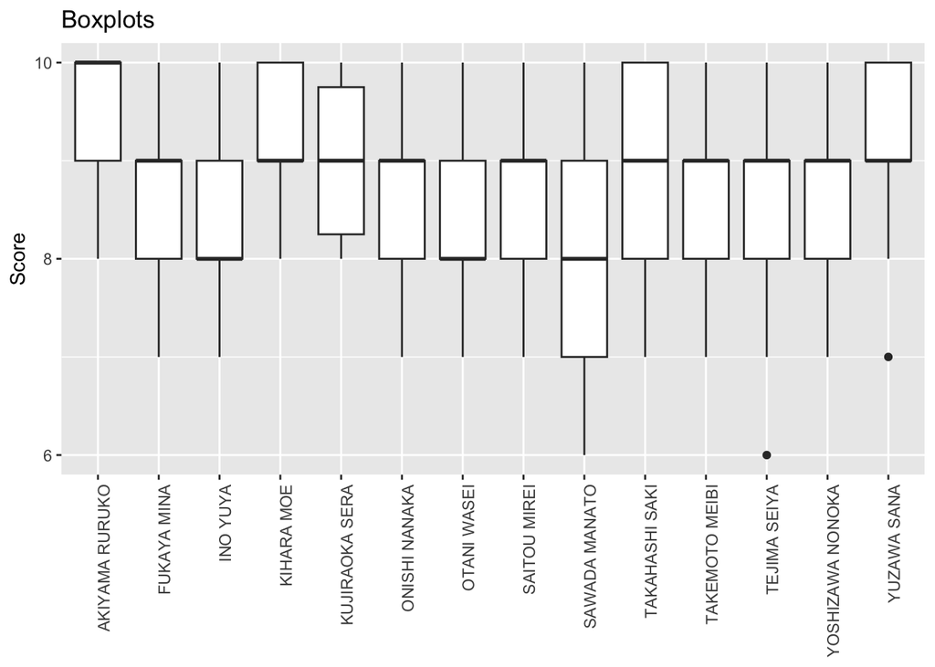

#### What did you like best about her presentation?

```
                  best
presenter          content delivery fluency grammar pronunciation slides
  AKIYAMA RURUKO        15        5       3       1             0      0
  FUKAYA MINA           10        1       3       2             0      6
  INO YUYA              15        2       1       1             0      3
  KIHARA MOE            11        5       4       1             2      2
  KUJIRAOKA SERA        13        1       2       0             1      4
  ONISHI NANAKA          8        2       3       1             4      5
  OTANI WASEI           17        1       1       2             0      0
  SAITOU MIREI          20        1       1       0             0      3
  SAWADA MANATO         16        2       1       0             2      2
  TAKAHASHI SAKI        19        2       0       1             0      1
  TAKEMOTO MEIBI        13        1       2       2             2      4
  TEJIMA SEIYA           4        2       6       0             1     10
  YOSHIZAWA NONOKA      14        2       1       0             0      6
  YUZAWA SANA           10        3       3       0             2      5
                  best
presenter          vocabulary
  AKIYAMA RURUKO            0
  FUKAYA MINA               0
  INO YUYA                  0
  KIHARA MOE                0
  KUJIRAOKA SERA            1
  ONISHI NANAKA             0
  OTANI WASEI               0
  SAITOU MIREI              0
  SAWADA MANATO             1
  TAKAHASHI SAKI            0
  TAKEMOTO MEIBI            0
  TEJIMA SEIYA              0
  YOSHIZAWA NONOKA          1
  YUZAWA SANA               0
```

#### What else did you like about her presentation?

```
                  good
presenter          content delivery fluency grammar pronunciation slides
  AKIYAMA RURUKO         3        3       8       1             5      3
  FUKAYA MINA            7        2       2       1             0     10
  INO YUYA               4        3       0       0             0     14
  KIHARA MOE             6        8       4       0             1      5
  KUJIRAOKA SERA         3        4       5       2             0      8
  ONISHI NANAKA          7        1       6       1             6      1
  OTANI WASEI            2        7       2       2             0      7
  SAITOU MIREI           3        3       3       0             2     14
  SAWADA MANATO          3        0       6       2             1     10
  TAKAHASHI SAKI         1        4       7       2             2      7
  TAKEMOTO MEIBI         6        5       4       1             0      8
  TEJIMA SEIYA           8        3       2       2             4      2
  YOSHIZAWA NONOKA       5        6       1       0             1      9
  YUZAWA SANA            6        2       5       1             3      5
                  good
presenter          vocabulary
  AKIYAMA RURUKO            1
  FUKAYA MINA               0
  INO YUYA                  1
  KIHARA MOE                1
  KUJIRAOKA SERA            0
  ONISHI NANAKA             1
  OTANI WASEI               1
  SAITOU MIREI              0
  SAWADA MANATO             2
  TAKAHASHI SAKI            0
  TAKEMOTO MEIBI            0
  TEJIMA SEIYA              2
  YOSHIZAWA NONOKA          2
  YUZAWA SANA               1
```

#### Improvement suggestion

```
                  improvement
presenter          content delivery fluency grammar nothing in particular
  AKIYAMA RURUKO         0        1       1       0                    21
  FUKAYA MINA            2        2       3       0                    11
  INO YUYA               0        1       5       0                     6
  KIHARA MOE             1        0       5       0                    16
  KUJIRAOKA SERA         0        3       4       0                    11
  ONISHI NANAKA          0        3       3       0                    12
  OTANI WASEI            0        0       2       1                     8
  SAITOU MIREI           0        7       2       0                    14
  SAWADA MANATO          2        6       2       0                    11
  TAKAHASHI SAKI         1        1       0       2                    16
  TAKEMOTO MEIBI         0        3       2       0                    13
  TEJIMA SEIYA           0        1       2       0                    12
  YOSHIZAWA NONOKA       0        0       8       1                     7
  YUZAWA SANA            1        0       1       0                    17
                  improvement
presenter          pronunciation slides vocabulary
  AKIYAMA RURUKO               0      0          1
  FUKAYA MINA                  3      1          0
  INO YUYA                     9      1          0
  KIHARA MOE                   1      1          1
  KUJIRAOKA SERA               2      1          1
  ONISHI NANAKA                2      2          1
  OTANI WASEI                  7      2          1
  SAITOU MIREI                 1      1          0
  SAWADA MANATO                2      0          1
  TAKAHASHI SAKI               1      2          0
  TAKEMOTO MEIBI               3      0          3
  TEJIMA SEIYA                 3      1          4
  YOSHIZAWA NONOKA             8      0          0
  YUZAWA SANA                  2      2          0
```

#### When did you submit today’s form?

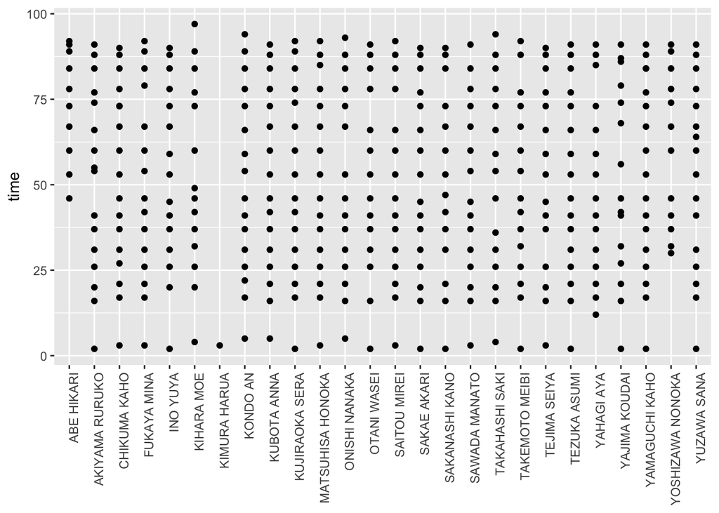

#### What was your role today?

```
                  role
name
  ABE HIKARI       10
  AKIYAMA RURUKO   16
  CHIKUMA KAHO     17
  FUKAYA MINA      15
  INO YUYA         15
  KIHARA MOE       14
  KIMURA HARUA      1
  KONDO AN         16
  KUBOTA ANNA      16
  KUJIRAOKA SERA   16
  MATSUHISA HONOKA 16
  ONISHI NANAKA    15
  OTANI WASEI      14
  SAITOU MIREI     15
  SAKAE AKARI      16
  SAKANASHI KANO   14
  SAWADA MANATO    15
  TAKAHASHI SAKI   15
  TAKEMOTO MEIBI   15
  TEJIMA SEIYA     15
  TEZUKA ASUMI     16
  YAHAGI AYA       15
  YAJIMA KOUDAI    15
  YAMAGUCHI KAHO   17
  YOSHIZAWA NONOKA 12
  YUZAWA SANA      16
```

#### Today’s key words

```
factor()
Levels:
```

#### Today’s vocabulary homework challenge

### Reflection

#### How was today?

```
integer(0)
```

```
today
 great!    good average
     15       8       2
```

#### What was good about today’s lesson?

| comment |
| --- |

| comment |
| --- |
| I learn a lot of new things. |
| Very interesting contents. |
| Everyone could do good presentation. |
| I could did a presentation. |
| I listened to a lot of presentations. |
| Everyone’s topic is interesting |
| Today’s presentation topic is so difficult but everyone introduced well |
| There are many interesting presentation today. I enjoyed watching and listening their presentations. |
| I could enjoy history of many things. |
| I was nervous, but I managed to speak in a way that got my message across. |
| I could do well on presentation. |
| I was able to give my presentation in loud voice. |
| Each presentation was so interesting. |
| I can learned about history. |
| It was interesting to know everyone’s interest. |
| I was able to listen to everyone’s presentations. |
| I was able to give my presentation smoothly. |
| I could make a presentation in clear voice. |
| I enjoyed classmates’ presentations. |
| I coud know meny new thing about art. |
| I could prepare for presentation well. |
| I can know a lot of things. There are many interesting content. |
| I could listen carefully my classmates’ presentations. |
| I could carry out my presentation. |
| I spoke loudly. |

#### What was not so good?

| comment |
| --- |

| comment |
| --- |
| Sometimes I can’t understand |
| Not anything. |
| nothing. |
| nothing in particular |
| I sometimes didn’t understand English. |
| Nothing |
| Nothing in particular |
| There were some parts that I couldn’t catch. |
| Nothing |
| I was late because I wasn’t feeling well, so I missed hearing from a few people. |
| It was difficult to speak without draft. |
| I can’t memorize everything |
| During my presentation, I couldn’t speak fluently. |
| Sometimes I was bored. |
| I didn’t make a presentation today. |
| I couldn’t stay focused all the tim |
| I couldn’t pronounce some words clearly. |
| I spoke quickly and it may have been difficult to hear. |
| Nothing. |
| I could not speak fluently and loudly. |
| It was difficult to speak fluently without the script. |
| Nothing |
| Sometimes I couldn’t catch up with the details of presentations’ content . |
| I couldn’t deliver well what I want to tell in my presentation. |
| I didn’t speak fluently. |

#### Who was interesting?

```
integer(0)
```

```
gold
  AKIYAMA RURUKO      YUZAWA SANA   TAKAHASHI SAKI YOSHIZAWA NONOKA
               9                4                4                1
  TAKEMOTO MEIBI     SAITOU MIREI    ONISHI NANAKA     KIMURA HARUA
               1                1                1                1
      KIHARA MOE         INO YUYA      FUKAYA MINA
               1                1                1
```

| gold | reason |
| --- | --- |

| gold | reason |
| --- | --- |
| AKIYAMA RURUKO | Because her presentation was interesting. |
| AKIYAMA RURUKO | Because her presentation’s topic was so interesting and the delivery or pronounciation were also good. |
| AKIYAMA RURUKO | Because it was so easy to listen to and interesting. |
| AKIYAMA RURUKO | Her delivery was very nice and the content was interesing. |
| AKIYAMA RURUKO | Her eyecontact was great. |
| AKIYAMA RURUKO | It was good that she asked the audience questions. |
| AKIYAMA RURUKO | The content was interesting and good slides. |
| AKIYAMA RURUKO | The content was very interesting! Also, her presentation skill was so nice. |
| AKIYAMA RURUKO | interesting content |
| FUKAYA MINA | She’s topic is art but interesting |
| INO YUYA | It was a topic I was interested in. |
| KIHARA MOE | She told us interesting content of Japanese yokai. |
| KIMURA HARUA | Her topic was interesting. |
| ONISHI NANAKA | Interesting |
| SAITOU MIREI | good content |
| TAKAHASHI SAKI | Her presentation was unique and interesting. |
| TAKAHASHI SAKI | I was interested in Tatsuya Tanaka’s minutiae art. |
| TAKAHASHI SAKI | The contents were so interested. |
| TAKAHASHI SAKI | used audience response |
| TAKEMOTO MEIBI | Very goof and writing in detail. |
| YOSHIZAWA NONOKA | Content is interesting |
| YUZAWA SANA | Because it was easy to hear and easy to see. |
| YUZAWA SANA | Her slide looks nice |
| YUZAWA SANA | Her slides were cute. |
| YUZAWA SANA | interesting and fun |

#### Who else was interesting?

```
integer(0)
```

```
silver
      KIHARA MOE     SAITOU MIREI   AKIYAMA RURUKO YOSHIZAWA NONOKA
               6                5                4                2
  TAKAHASHI SAKI   KUJIRAOKA SERA      YUZAWA SANA     TEJIMA SEIYA
               2                2                1                1
  TAKEMOTO MEIBI    SAWADA MANATO
               1                1
```

| silver | reason |
| --- | --- |

silver

reason

AKIYAMA RURUKO

Her preparation was vivid.

AKIYAMA RURUKO

Her slid was good.

AKIYAMA RURUKO

Her voice is very clearly.

AKIYAMA RURUKO

used audience response

KIHARA MOE

Because her talking was active.

KIHARA MOE

Experience in visiting the exhibition was added to her presentation.

KIHARA MOE

Her content was interesting.

KIHARA MOE

Her presentation was fun to listen.

KIHARA MOE

Her theme was interesting.9

KIHARA MOE

Nice eye contact.

KUJIRAOKA SERA

Interesting slide contents

KUJIRAOKA SERA

She speeches arts of history and it was so interesting.

SAITOU MIREI

- It was easy to understand because I already knew a lot about it.

SAITOU MIREI

Because it was a topic I like.

SAITOU MIREI

Content is interesting

SAITOU MIREI

I also like K-POP, so I enjoyed her theme.

SAITOU MIREI

Interesting

SAWADA MANATO

nice slides

TAKAHASHI SAKI

The content was so interesting and I want to know about Tatsuya’s art more.

TAKAHASHI SAKI

The unique content was fun.

TAKEMOTO MEIBI

she could do fun presentation.

TEJIMA SEIYA

interesting content

YOSHIZAWA NONOKA

I was also interested in the content, so I found out what I wanted to know.

YOSHIZAWA NONOKA

She used photos to explain her presentation.

YUZAWA SANA

Because she could deliver what she want to tell in her presentation. The content was also good.

### Participation

#### Warmup question counts

```
name
        KONDO AN   AKIYAMA RURUKO     TEZUKA ASUMI   TAKEMOTO MEIBI
              14               14               13               13
  TAKAHASHI SAKI      SAKAE AKARI MATSUHISA HONOKA   KUJIRAOKA SERA
              13               13               13               13
    KIMURA HARUA       KIHARA MOE      FUKAYA MINA      YUZAWA SANA
              13               13               13               12
YOSHIZAWA NONOKA   SAKANASHI KANO      OTANI WASEI    ONISHI NANAKA
              12               12               12               12
    CHIKUMA KAHO    YAJIMA KOUDAI    KOJIMA TAKUMI         INO YUYA
              12               11               11               11
      ABE HIKARI   YAMAGUCHI KAHO       YAHAGI AYA    SAWADA MANATO
              11               10               10               10
    SAITOU MIREI     TEJIMA SEIYA     NEGISHI HANA      KUBOTA ANNA
              10                9                9                9
```

```
                  week
name               16 17 18 19 20 21 22 23 24 25 26 27 28
  ABE HIKARI        1  1  0  1  1  1  1  1  1  0  1  1  1
  AKIYAMA RURUKO    1  1  1  1  1  1  1  1  1  1  1  1  2
  CHIKUMA KAHO      1  1  1  1  1  1  1  1  1  1  1  0  1
  FUKAYA MINA       1  1  1  1  1  1  1  1  1  1  1  1  1
  INO YUYA          1  1  1  0  1  1  1  1  0  1  1  1  1
  KIHARA MOE        1  1  1  1  1  1  1  1  1  1  1  1  1
  KIMURA HARUA      1  1  1  1  1  1  1  1  1  1  1  1  1
  KOJIMA TAKUMI     1  1  1  1  1  1  0  1  1  1  1  1  0
  KONDO AN          1  1  2  1  1  1  1  1  1  1  1  1  1
  KUBOTA ANNA       1  1  1  0  0  1  0  1  0  1  1  1  1
  KUJIRAOKA SERA    1  1  1  1  1  1  1  1  1  1  1  1  1
  MATSUHISA HONOKA  1  1  1  1  1  1  1  1  1  1  1  1  1
  NEGISHI HANA      1  1  1  0  1  1  1  1  0  0  1  1  0
  ONISHI NANAKA     1  1  1  1  1  0  1  1  1  1  1  1  1
  OTANI WASEI       1  1  1  1  0  1  1  1  1  1  1  1  1
  SAITOU MIREI      1  1  0  1  1  0  1  0  1  1  1  1  1
  SAKAE AKARI       1  1  1  1  1  1  1  1  1  1  1  1  1
  SAKANASHI KANO    1  1  1  1  1  1  1  1  1  1  1  0  1
  SAWADA MANATO     1  0  1  1  0  1  1  1  0  1  1  1  1
  TAKAHASHI SAKI    1  1  1  1  1  1  1  1  1  1  1  1  1
  TAKEMOTO MEIBI    1  1  1  1  1  1  1  1  1  1  1  1  1
  TEJIMA SEIYA      1  1  1  0  1  1  1  0  0  1  1  0  1
  TEZUKA ASUMI      1  1  1  1  1  1  1  1  1  1  1  1  1
  YAHAGI AYA        1  1  0  0  1  1  1  1  1  1  0  1  1
  YAJIMA KOUDAI     1  1  1  1  0  1  1  1  1  1  0  1  1
  YAMAGUCHI KAHO    1  1  1  0  1  1  1  1  0  1  1  0  1
  YOSHIZAWA NONOKA  1  1  1  1  1  1  1  1  1  0  1  1  1
  YUZAWA SANA       1  0  1  1  1  1  1  1  1  1  1  1  1
```

#### Discussion feedback counts

```
name
    TEZUKA ASUMI      FUKAYA MINA   TAKAHASHI SAKI      SAKAE AKARI
              45               45               44               44
  KUJIRAOKA SERA   AKIYAMA RURUKO   TAKEMOTO MEIBI      OTANI WASEI
              44               44               43               43
   ONISHI NANAKA MATSUHISA HONOKA    KOJIMA TAKUMI     KIMURA HARUA
              43               43               43               42
      KIHARA MOE      YUZAWA SANA   SAKANASHI KANO     CHIKUMA KAHO
              41               39               39               38
YOSHIZAWA NONOKA         KONDO AN       ABE HIKARI    YAJIMA KOUDAI
              37               35               34               33
     KUBOTA ANNA         INO YUYA       YAHAGI AYA     SAITOU MIREI
              33               33               32               32
  YAMAGUCHI KAHO     NEGISHI HANA    SAWADA MANATO     TEJIMA SEIYA
              27               27               26               21
```

```
                  week
name               16 17 18 19 20 21 22 23 24 25 26 27
  ABE HIKARI        4  5  0  4  5  0  0  6  0  0  5  5
  AKIYAMA RURUKO    6  0  5  4  5  0  1  6  6  6  0  5
  CHIKUMA KAHO      6  6  0  4  5  0  0  6  6  0  5  0
  FUKAYA MINA       6  6  5  0  5  0  0  6  6  6  5  0
  INO YUYA          5  6  5  0  1  0  0  0  0  6  5  5
  KIHARA MOE        1  6  4  4  4  0  0  6  5  6  0  5
  KIMURA HARUA      6  1  5  4  5  0  0  6  0  5  5  5
  KOJIMA TAKUMI     6  6  0  4  5  0  0  6  6  0  5  5
  KONDO AN          6  6  8  0  5  0  0  5  0  0  0  5
  KUBOTA ANNA       6  6  5  0  0  0  0  0  0  6  5  5
  KUJIRAOKA SERA    6  6  5  4  1  0  0  0  6  6  5  5
  MATSUHISA HONOKA  6  6  5  4  0  0  0  6  6  0  5  5
  NEGISHI HANA      5  6  5  0  0  0  0  6  0  0  5  0
  ONISHI NANAKA     6  6  5  4  0  0  0  6  6  0  5  5
  OTANI WASEI       6  6  5  4  0  0  0  6  0  6  5  5
  SAITOU MIREI      6  0  0  4  5  0  0  0  6  6  5  0
  SAKAE AKARI       6  6  0  4  5  0  0  6  6  1  5  5
  SAKANASHI KANO    6  6  5  0  5  0  0  6  0  6  5  0
  SAWADA MANATO     1  0  5  4  0  0  0  0  0  6  5  5
  TAKAHASHI SAKI    6  6  5  0  4  0  0  1  6  6  5  5
  TAKEMOTO MEIBI    0  6  5  4  5  0  0  6  1  6  5  5
  TEJIMA SEIYA      6  0  5  0  5  0  0  0  0  5  0  0
  TEZUKA ASUMI      6  6  1  4  5  0  0  6  6  6  5  0
  YAHAGI AYA        6  0  0  0  5  0  0  0  6  6  4  5
  YAJIMA KOUDAI     6  5  0  4  0  2  0  6  0  6  0  4
  YAMAGUCHI KAHO    0  5  5  0  5  0  0  6  0  6  0  0
  YOSHIZAWA NONOKA  6  1  6  4  5  0  0  5  6  0  4  0
  YUZAWA SANA       2  0  6  4  5  0  0  6  6  0  5  5
```

#### Presentation feedback counts

```
name
  YAMAGUCHI KAHO     CHIKUMA KAHO     TEZUKA ASUMI     TEJIMA SEIYA
              42               42               41               41
  TAKAHASHI SAKI      SAKAE AKARI MATSUHISA HONOKA   KUJIRAOKA SERA
              41               41               41               41
        INO YUYA      YUZAWA SANA       YAHAGI AYA   TAKEMOTO MEIBI
              41               40               40               40
   SAWADA MANATO         KONDO AN   AKIYAMA RURUKO      OTANI WASEI
              40               40               40               39
     FUKAYA MINA YOSHIZAWA NONOKA   SAKANASHI KANO       KIHARA MOE
              39               37               37               37
   YAJIMA KOUDAI       ABE HIKARI     KIMURA HARUA     SAITOU MIREI
              36               35               28               27
    NEGISHI HANA    KOJIMA TAKUMI    ONISHI NANAKA      KUBOTA ANNA
              27               27               26               26
```

```
                  week
name               21 22 28
  ABE HIKARI       12 15  8
  AKIYAMA RURUKO   13 14 13
  CHIKUMA KAHO     12 15 15
  FUKAYA MINA      11 15 13
  INO YUYA         13 15 13
  KIHARA MOE       12 13 12
  KIMURA HARUA     13 15  0
  KOJIMA TAKUMI    13 14  0
  KONDO AN         12 14 14
  KUBOTA ANNA      12  0 14
  KUJIRAOKA SERA   13 14 14
  MATSUHISA HONOKA 13 14 14
  NEGISHI HANA     12 15  0
  ONISHI NANAKA     0 13 13
  OTANI WASEI      13 14 12
  SAITOU MIREI      0 14 13
  SAKAE AKARI      12 15 14
  SAKANASHI KANO   13 12 12
  SAWADA MANATO    12 15 13
  TAKAHASHI SAKI   13 15 13
  TAKEMOTO MEIBI   13 14 13
  TEJIMA SEIYA     13 15 13
  TEZUKA ASUMI     12 15 14
  YAHAGI AYA       12 15 13
  YAJIMA KOUDAI    10 13 13
  YAMAGUCHI KAHO   13 14 15
  YOSHIZAWA NONOKA 13 14 10
  YUZAWA SANA      13 13 14
```

#### How was today counts

```
name
     YUZAWA SANA     TEZUKA ASUMI   TAKEMOTO MEIBI   TAKAHASHI SAKI
              13               13               13               13
     SAKAE AKARI MATSUHISA HONOKA   KUJIRAOKA SERA       KIHARA MOE
              13               13               13               13
  AKIYAMA RURUKO YOSHIZAWA NONOKA   SAKANASHI KANO      OTANI WASEI
              13               12               12               12
   KOJIMA TAKUMI      FUKAYA MINA     CHIKUMA KAHO    YAJIMA KOUDAI
              12               12               12               11
      YAHAGI AYA    ONISHI NANAKA         KONDO AN     KIMURA HARUA
              11               11               11               11
        INO YUYA       ABE HIKARI   YAMAGUCHI KAHO    SAWADA MANATO
              11               11               10               10
    SAITOU MIREI     TEJIMA SEIYA     NEGISHI HANA      KUBOTA ANNA
              10                9                9                9
```

```
                  week
name               16 17 18 19 20 21 22 23 24 25 26 27 28
  ABE HIKARI        1  1  0  1  1  1  1  1  1  0  1  1  1
  AKIYAMA RURUKO    1  1  1  1  1  1  1  1  1  1  1  1  1
  CHIKUMA KAHO      1  1  1  1  1  1  1  1  1  1  1  0  1
  FUKAYA MINA       1  1  1  1  0  1  1  1  1  1  1  1  1
  INO YUYA          1  1  1  0  1  1  1  1  0  1  1  1  1
  KIHARA MOE        1  1  1  1  1  1  1  1  1  1  1  1  1
  KIMURA HARUA      1  1  1  1  0  1  1  1  1  1  1  1  0
  KOJIMA TAKUMI     1  1  1  1  1  1  1  1  1  1  1  1  0
  KONDO AN          1  1  1  1  1  1  1  1  0  0  1  1  1
  KUBOTA ANNA       1  1  1  0  0  1  0  1  0  1  1  1  1
  KUJIRAOKA SERA    1  1  1  1  1  1  1  1  1  1  1  1  1
  MATSUHISA HONOKA  1  1  1  1  1  1  1  1  1  1  1  1  1
  NEGISHI HANA      1  1  1  0  1  1  1  1  0  0  1  1  0
  ONISHI NANAKA     1  1  1  1  0  0  1  1  1  1  1  1  1
  OTANI WASEI       1  1  1  1  0  1  1  1  1  1  1  1  1
  SAITOU MIREI      1  1  0  1  1  0  1  0  1  1  1  1  1
  SAKAE AKARI       1  1  1  1  1  1  1  1  1  1  1  1  1
  SAKANASHI KANO    1  1  1  1  1  1  1  1  1  1  1  0  1
  SAWADA MANATO     1  0  1  1  0  1  1  1  0  1  1  1  1
  TAKAHASHI SAKI    1  1  1  1  1  1  1  1  1  1  1  1  1
  TAKEMOTO MEIBI    1  1  1  1  1  1  1  1  1  1  1  1  1
  TEJIMA SEIYA      1  1  1  0  1  1  1  0  0  1  1  0  1
  TEZUKA ASUMI      1  1  1  1  1  1  1  1  1  1  1  1  1
  YAHAGI AYA        1  1  0  0  1  1  1  1  1  1  1  1  1
  YAJIMA KOUDAI     1  1  1  1  0  1  1  1  1  1  0  1  1
  YAMAGUCHI KAHO    1  1  1  0  1  1  1  1  0  1  1  0  1
  YOSHIZAWA NONOKA  1  1  1  1  1  1  1  1  1  0  1  1  1
  YUZAWA SANA       2  0  1  1  1  1  1  1  1  1  1  1  1
```

### Term report

#### All vocabulary

```
  [1] abroad               accident             addiction
  [4] additives            adult                air plane
  [7] allergies            annoying             assignment
 [10] atmosphere           automation           balance
 [13] bullying             burden               cashless
 [16] casual               characteristic       childish
 [19] choice               clothing             common
 [22] communication        community            competition
 [25] comprehensive        compulsory           concentration
 [28] confidence           conflict             consultation
 [31] consumption          countryside          creation
 [34] crime                critical thinking    decision
 [37] depends              despite              directly
 [40] disappear            dislike              distance
 [43] diversity            elder                elderly
```

[output cut: 35 more lines]

#### Punctuality

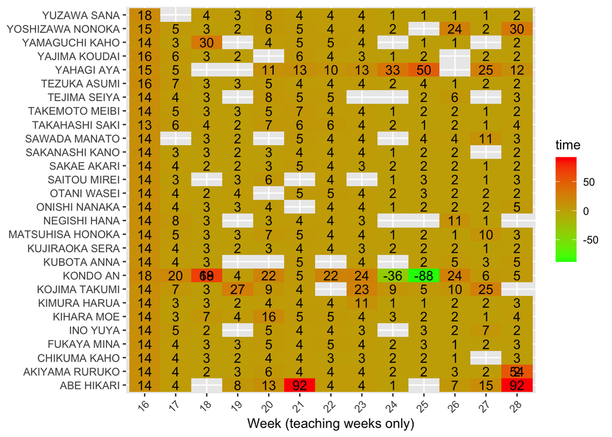

#### Current participation score out of 35

```
               name Freq errors violations sub_total total
1        ABE HIKARI   91      4          0        83  26.2
2    AKIYAMA RURUKO  111      1          0       109  34.4
3      CHIKUMA KAHO  104      1          0       102  32.2
4       FUKAYA MINA  109      0          0       109  34.4
5          INO YUYA   96      0          0        96  30.3
6        KIHARA MOE  104      1          0       102  32.2
7      KIMURA HARUA   94      1          0        92  29.0
8     KOJIMA TAKUMI   93      0          0        93  29.3
9          KONDO AN  100      3          0        94  29.6
10      KUBOTA ANNA   77      0          0        77  24.3
11   KUJIRAOKA SERA  111      0          0       111  35.0
12 MATSUHISA HONOKA  110      0          0       110  34.7
13     NEGISHI HANA   72      0          0        72  22.7
14    ONISHI NANAKA   92      0          0        92  29.0
15      OTANI WASEI  106      0          0       106  33.4
16     SAITOU MIREI   79      0          0        79  24.9
17      SAKAE AKARI  111      0          0       111  35.0
18   SAKANASHI KANO  100      0          0       100  31.5
19    SAWADA MANATO   86      1          0        84  26.5
20   TAKAHASHI SAKI  111      1          0       109  34.4
21   TAKEMOTO MEIBI  109      1          0       107  33.7
22     TEJIMA SEIYA   80      0          0        80  25.2
23     TEZUKA ASUMI  112      1          0       110  34.7
24       YAHAGI AYA   93      0          0        93  29.3
25    YAJIMA KOUDAI   91      0          0        91  28.7
26   YAMAGUCHI KAHO   89      1          0        87  27.4
27 YOSHIZAWA NONOKA   98      1          0        96  30.3
28      YUZAWA SANA  104      3          0        98  30.9
```

*Thank you for your diligence, your honesty, and your participation!*